# ALE_Experiment

Kenzie Cooke

2024-06-16

# 2/19 to 3/23 (t1-t3)

After fixing lights, took new data point. 33 total days of growth

## Total calfification by ta

Wet weight converted to dry weight, corrected for density and standardized to initial surface area.

### Linear mixed effect model

to check for random effects (tank, genotype)  
BW from t1 to t3, growth ~ ta, 1|geno, 1|tank

```
## Linear mixed model fit by REML. t-tests use Satterthwaite's method [
## lmerModLmerTest]
## Formula: gr_sa ~ ta_mmol + (1 | geno) + (1 | tank)
##    Data: bw.2
##
## REML criterion at convergence: -18.3
##
## Scaled residuals:
##      Min       1Q   Median       3Q      Max
## -1.52156 -0.76504 -0.08502  0.71612  2.29665
##
## Random effects:
##  Groups   Name        Variance Std.Dev.
##  tank     (Intercept) 0.001164 0.03411
##  geno     (Intercept) 0.003134 0.05598
##  Residual             0.028081 0.16757
## Number of obs: 40, groups:  tank, 4; geno, 3
##
## Fixed effects:
##             Estimate Std. Error       df t value Pr(>|t|)
## (Intercept) -0.14740    0.13703 35.67225  -1.076    0.289
## ta_mmol      0.21962    0.03523 33.46123   6.234 4.58e-07 ***
## ---
## Signif. codes:  0 '***' 0.001 '**' 0.01 '*' 0.05 '.' 0.1 ' ' 1
##
## Correlation of Fixed Effects:
##         (Intr)
## ta_mmol -0.943
```

```
## Type III Analysis of Variance Table with Satterthwaite's method
##         Sum Sq Mean Sq NumDF  DenDF F value    Pr(>F)
## ta_mmol 1.0914  1.0914     1 33.461  38.866 4.577e-07 ***
## ---
## Signif. codes:  0 '***' 0.001 '**' 0.01 '*' 0.05 '.' 0.1 ' ' 1
```

```
## ANOVA-like table for random-effects: Single term deletions
##
## Model:
## gr_sa ~ ta_mmol + (1 | geno) + (1 | tank)
##            npar logLik      AIC     LRT Df Pr(>Chisq)
## <none>        5 9.1535  -8.3071
## (1 | geno)    4 8.7768  -9.5535 0.75354  1     0.3854
## (1 | tank)    4 9.0659 -10.1318 0.17533  1     0.6754
```

```
## Backward reduced random-effect table:
##
##            Eliminated npar logLik      AIC     LRT Df Pr(>Chisq)
## <none>                   5 9.1535  -8.3071
## (1 | tank)          1    4 9.0659 -10.1318 0.17533  1     0.6754
## (1 | geno)          2    3 8.7235 -11.4471 0.68466  1     0.4080
##
## Backward reduced fixed-effect table:
##         Eliminated Df Sum of Sq    RSS     AIC F value    Pr(>F)
## ta_mmol          0  1    1.0983 2.2732 -112.71  35.526 6.452e-07 ***
## ---
## Signif. codes:  0 '***' 0.001 '**' 0.01 '*' 0.05 '.' 0.1 ' ' 1
##
## Model found:
## gr_sa ~ ta_mmol
```

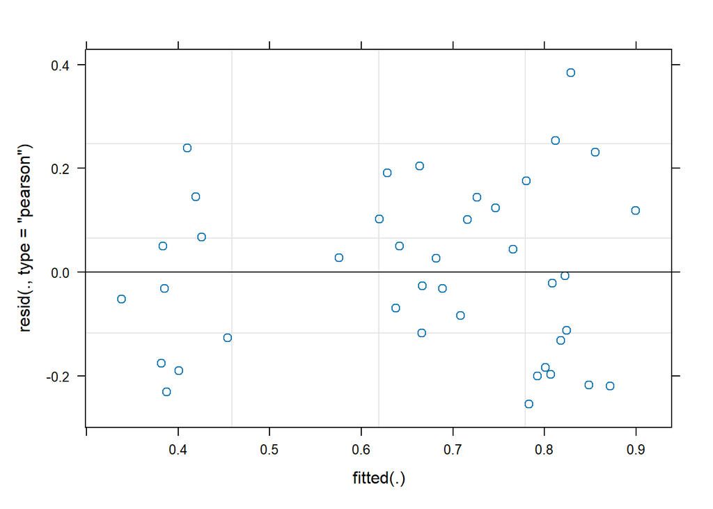

Shows no significant tank or genotype effect. Suggests appropriate model is growth ~ ta. Create regular linear model and check residuals:

### Linear model, bw growth ~ ta

```
##
## Call:
## lm(formula = gr_sa ~ ta_mmol, data = bw.2)
##
## Residuals:
##      Min       1Q   Median       3Q      Max
## -0.27762 -0.15434 -0.00852  0.14678  0.44663
##
## Coefficients:
##             Estimate Std. Error t value Pr(>|t|)
## (Intercept) -0.13995    0.13735  -1.019    0.315
## ta_mmol      0.21908    0.03676   5.960 6.45e-07 ***
## ---
## Signif. codes:  0 '***' 0.001 '**' 0.01 '*' 0.05 '.' 0.1 ' ' 1
##
## Residual standard error: 0.1758 on 38 degrees of freedom
## Multiple R-squared:  0.4832, Adjusted R-squared:  0.4696
## F-statistic: 35.53 on 1 and 38 DF,  p-value: 6.452e-07
```

```
## Analysis of Variance Table
##
## Response: gr_sa
##           Df Sum Sq Mean Sq F value    Pr(>F)
## ta_mmol    1 1.0983 1.09835  35.526 6.452e-07 ***
## Residuals 38 1.1748 0.03092
## ---
## Signif. codes:  0 '***' 0.001 '**' 0.01 '*' 0.05 '.' 0.1 ' ' 1
```

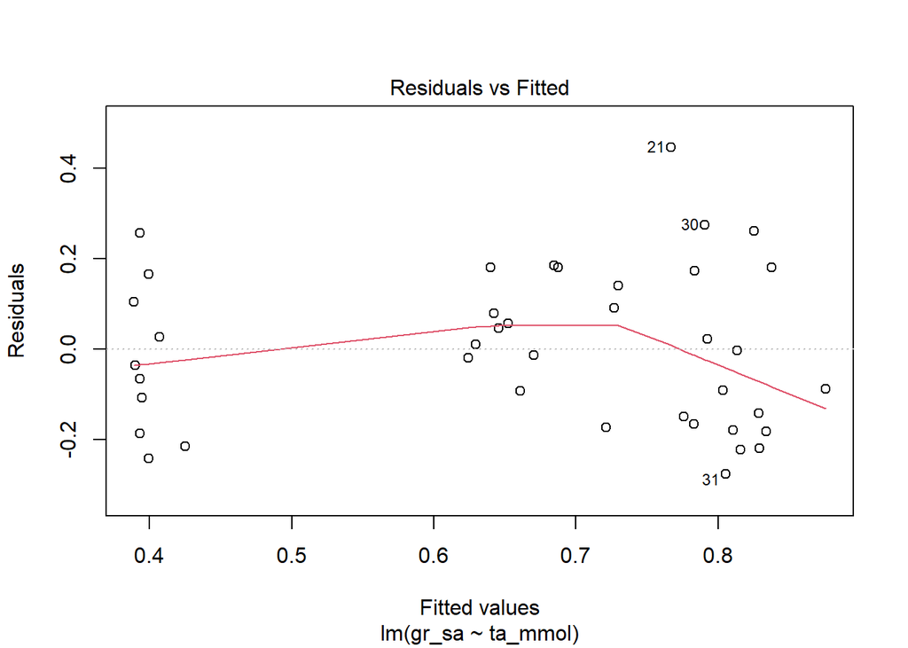

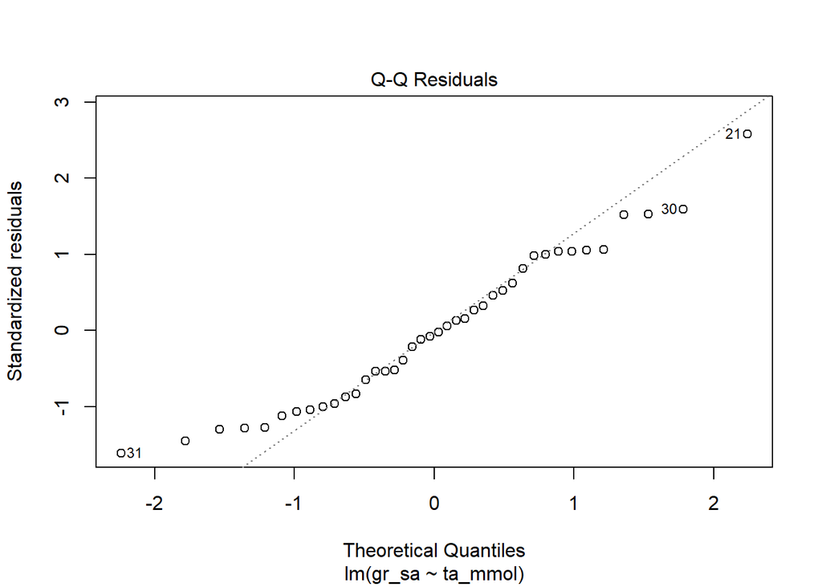

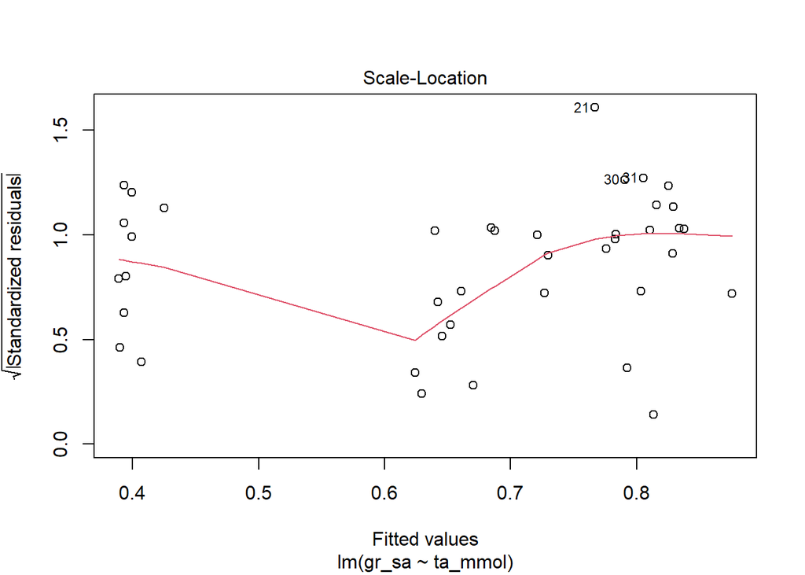

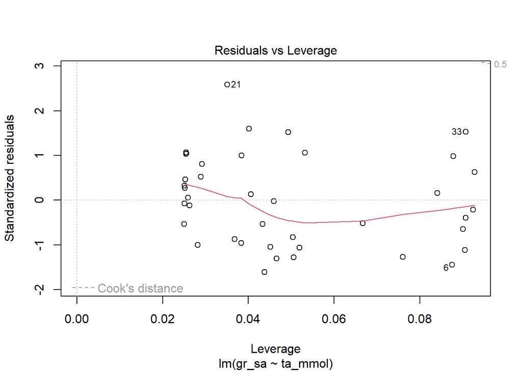

## Linear extension by TA

### linear mixed effect models

#### LE via ImageJ (t1-t3)

```
## Linear mixed model fit by REML. t-tests use Satterthwaite's method [
## lmerModLmerTest]
## Formula: gr_t1t3 ~ ta_mmol + (1 | geno) + (1 | tank)
##    Data: le
##
## REML criterion at convergence: -148.3
##
## Scaled residuals:
##     Min      1Q  Median      3Q     Max
## -2.0585 -0.5947 -0.0384  0.5662  2.2390
##
## Random effects:
##  Groups   Name        Variance  Std.Dev.
##  tank     (Intercept) 0.000e+00 0.000000
##  geno     (Intercept) 7.492e-05 0.008656
##  Residual             9.529e-04 0.030869
## Number of obs: 40, groups:  tank, 4; geno, 3
##
## Fixed effects:
##              Estimate Std. Error        df t value Pr(>|t|)
## (Intercept) -0.010169   0.024776 36.928248  -0.410   0.6839
## ta_mmol      0.015429   0.006476 36.666579   2.383   0.0225 *
## ---
## Signif. codes:  0 '***' 0.001 '**' 0.01 '*' 0.05 '.' 0.1 ' ' 1
##
## Correlation of Fixed Effects:
##         (Intr)
## ta_mmol -0.959
## optimizer (nloptwrap) convergence code: 0 (OK)
## boundary (singular) fit: see help('isSingular')
```

```
## Type III Analysis of Variance Table with Satterthwaite's method
##           Sum Sq  Mean Sq NumDF  DenDF F value  Pr(>F)
## ta_mmol 0.005409 0.005409     1 36.667  5.6765 0.02249 *
## ---
## Signif. codes:  0 '***' 0.001 '**' 0.01 '*' 0.05 '.' 0.1 ' ' 1
```

```
## ANOVA-like table for random-effects: Single term deletions
##
## Model:
## gr_t1t3 ~ ta_mmol + (1 | geno) + (1 | tank)
##            npar logLik     AIC    LRT Df Pr(>Chisq)
## <none>        5 74.142 -138.28
## (1 | geno)    4 73.782 -139.56 0.7198  1     0.3962
## (1 | tank)    4 74.142 -140.28 0.0000  1     1.0000
```

```
## Backward reduced random-effect table:
##
##            Eliminated npar logLik     AIC    LRT Df Pr(>Chisq)
## <none>                   5 74.142 -138.28
## (1 | tank)          1    4 74.142 -140.28 0.0000  1     1.0000
## (1 | geno)          2    3 73.782 -141.56 0.7198  1     0.3962
##
## Backward reduced fixed-effect table:
##         Eliminated Df Sum of Sq      RSS     AIC F value  Pr(>F)
## ta_mmol          0  1 0.0050135 0.043286 -271.15  4.9779 0.03165 *
## ---
## Signif. codes:  0 '***' 0.001 '**' 0.01 '*' 0.05 '.' 0.1 ' ' 1
##
## Model found:
## gr_t1t3 ~ ta_mmol
```

```
## Linear mixed model fit by REML. t-tests use Satterthwaite's method [
## lmerModLmerTest]
## Formula: gr_t1t3 ~ ta_mmol * geno + (1 | tank)
##    Data: le
##
## REML criterion at convergence: -125.6
##
## Scaled residuals:
##     Min      1Q  Median      3Q     Max
## -2.1262 -0.5356  0.1579  0.5349  1.7629
##
## Random effects:
##  Groups   Name        Variance  Std.Dev.
##  tank     (Intercept) 0.0000000 0.00000
##  Residual             0.0009772 0.03126
## Number of obs: 40, groups:  tank, 4
##
## Fixed effects:
##                Estimate Std. Error        df t value Pr(>|t|)
## (Intercept)    0.004146   0.036039 34.000000   0.115    0.909
## ta_mmol        0.014087   0.009900 34.000000   1.423    0.164
## genoM         -0.064009   0.064893 34.000000  -0.986    0.331
## genoS         -0.005618   0.055905 34.000000  -0.100    0.921
## ta_mmol:genoM  0.015327   0.017248 34.000000   0.889    0.380
## ta_mmol:genoS -0.004373   0.014991 34.000000  -0.292    0.772
##
## Correlation of Fixed Effects:
##             (Intr) ta_mml genoM  genoS  t_mm:M
## ta_mmol     -0.978
## genoM       -0.555  0.543
## genoS       -0.645  0.630  0.358
## ta_mmol:gnM  0.561 -0.574 -0.980 -0.362
## ta_mmol:gnS  0.646 -0.660 -0.359 -0.979  0.379
## optimizer (nloptwrap) convergence code: 0 (OK)
## boundary (singular) fit: see help('isSingular')
```

```
## Type III Analysis of Variance Table with Satterthwaite's method
##                 Sum Sq   Mean Sq NumDF DenDF F value  Pr(>F)
## ta_mmol      0.0065236 0.0065236     1    34  6.6759 0.01424 *
## geno         0.0010223 0.0005111     2    34  0.5231 0.59739
## ta_mmol:geno 0.0012226 0.0006113     2    34  0.6256 0.54100
## ---
## Signif. codes:  0 '***' 0.001 '**' 0.01 '*' 0.05 '.' 0.1 ' ' 1
```

```
## Backward reduced random-effect table:
##
##            Eliminated npar logLik     AIC LRT Df Pr(>Chisq)
## <none>                   8  62.78 -109.56
## (1 | tank)          1    7  62.78 -111.56   0  1          1
##
## Backward reduced fixed-effect table:
##              Eliminated Df Sum of Sq      RSS     AIC F value  Pr(>F)
## ta_mmol:geno          1  2 0.0012226 0.034447 -274.29  0.6256 0.54100
## geno                  2  2 0.0038253 0.038272 -274.08  1.9989 0.15025
## ta_mmol               0  1 0.0050135 0.043286 -271.15  4.9779 0.03165 *
## ---
## Signif. codes:  0 '***' 0.001 '**' 0.01 '*' 0.05 '.' 0.1 ' ' 1
##
## Model found:
## gr_t1t3 ~ ta_mmol
```

Significant effect of ta on linear extension, no sig effect of tank or geno.

Most simple model: gr_t1t3 ~ ta anova results: p=0.032

```
##
## Call:
## lm(formula = gr_t1t3 ~ ta_mmol, data = le)
##
## Residuals:
##       Min        1Q    Median        3Q       Max
## -0.057874 -0.022652 -0.004399  0.020996  0.070595
##
## Coefficients:
##              Estimate Std. Error t value Pr(>|t|)
## (Intercept) -0.007608   0.024790  -0.307   0.7606
## ta_mmol      0.014802   0.006634   2.231   0.0317 *
## ---
## Signif. codes:  0 '***' 0.001 '**' 0.01 '*' 0.05 '.' 0.1 ' ' 1
##
## Residual standard error: 0.03174 on 38 degrees of freedom
## Multiple R-squared:  0.1158, Adjusted R-squared:  0.09256
## F-statistic: 4.978 on 1 and 38 DF,  p-value: 0.03165
```

```
## Analysis of Variance Table
##
## Response: gr_t1t3
##           Df   Sum Sq   Mean Sq F value  Pr(>F)
## ta_mmol    1 0.005014 0.0050135  4.9779 0.03165 *
## Residuals 38 0.038272 0.0010072
## ---
## Signif. codes:  0 '***' 0.001 '**' 0.01 '*' 0.05 '.' 0.1 ' ' 1
```

Individual regressions by genotype (S, C, M):

```
## # A tibble: 6 × 18
## # Groups:   geno [3]
##   geno  term        estimate std.error statistic p.value r.squared adj.r.squared
##   <fct> <chr>          <dbl>     <dbl>     <dbl>   <dbl>     <dbl>         <dbl>
## 1 C     (Intercept)  0.00415   0.0431     0.0962   0.925    0.0862        0.0253
## 2 C     ta_mmol      0.0141    0.0118     1.19     0.253    0.0862        0.0253
## 3 M     (Intercept) -0.0599    0.0628    -0.954    0.372    0.314         0.216
## 4 M     ta_mmol      0.0294    0.0164     1.79     0.116    0.314         0.216
## 5 S     (Intercept) -0.00147   0.0216    -0.0680   0.947    0.195         0.128
## 6 S     ta_mmol      0.00971   0.00570    1.70     0.114    0.195         0.128
## # ℹ 10 more variables: sigma <dbl>, statistic.1 <dbl>, p.value.1 <dbl>,
## #   df <dbl>, logLik <dbl>, AIC <dbl>, BIC <dbl>, deviance <dbl>,
## #   df.residual <int>, nobs <int>
```

Ana: The individual regressions are not significant. I guess that does not matter since genotype was not significant, so in theory all data should be ran together?

## Scatter plots with regression

### Total calcification

#### Linear regression

BW from t1 to t3 w linear regression  
Growth standardized to initial surface area:

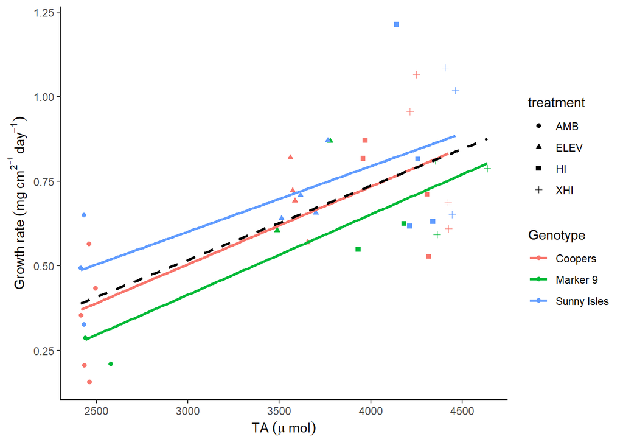

Growth standardized to initial mass:

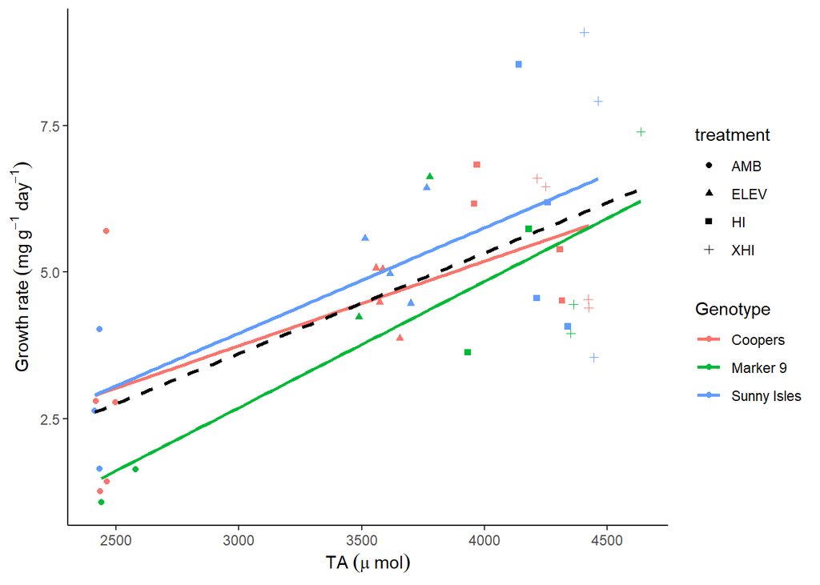

#### Non-linear regression

BW from t1 to t3 with non-linear regression  
growth standardized to surface area

Check fit of log regression:

```
##
## Call:
## lm(formula = gr_sa ~ log(ta), data = bw.2)
##
## Residuals:
##      Min       1Q   Median       3Q      Max
## -0.27317 -0.15576 -0.01542  0.13821  0.44314
##
## Coefficients:
##             Estimate Std. Error t value Pr(>|t|)
## (Intercept)  -5.3549     0.9795  -5.467 3.06e-06 ***
## log(ta)       0.7355     0.1197   6.145 3.60e-07 ***
## ---
## Signif. codes:  0 '***' 0.001 '**' 0.01 '*' 0.05 '.' 0.1 ' ' 1
##
## Residual standard error: 0.1732 on 38 degrees of freedom
## Multiple R-squared:  0.4984, Adjusted R-squared:  0.4852
## F-statistic: 37.76 on 1 and 38 DF,  p-value: 3.599e-07
```

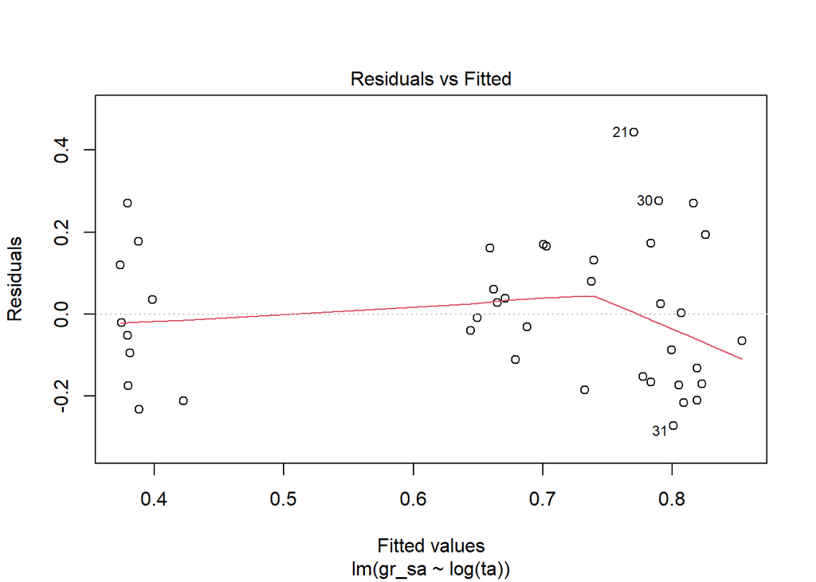

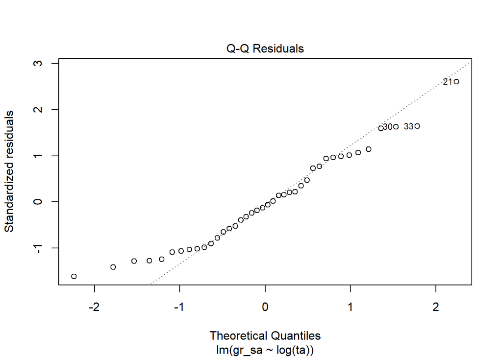

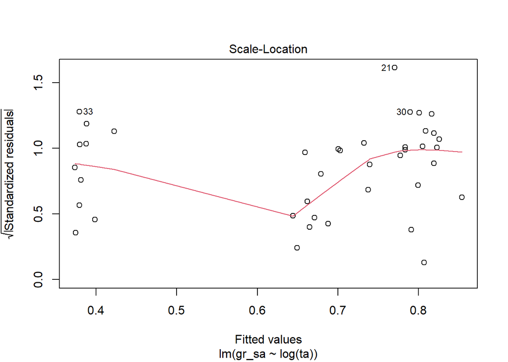

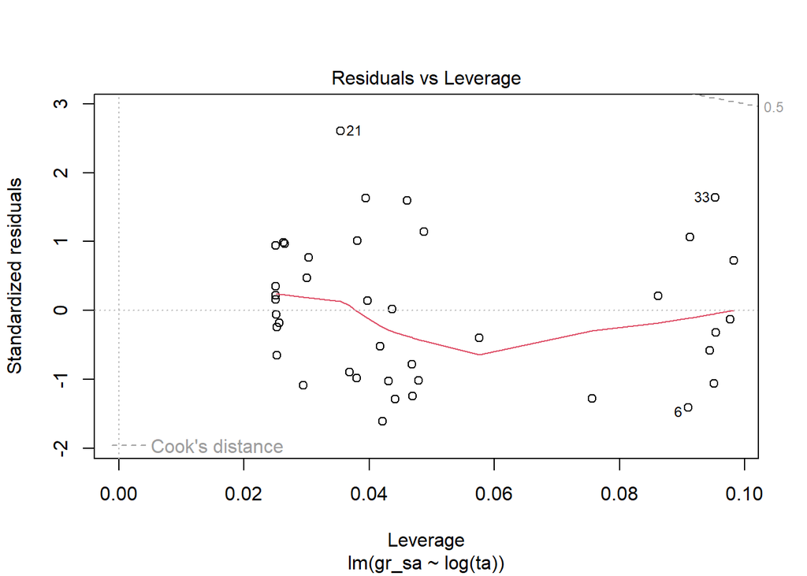

check fit of non log regression

```
##
## Call:
## lm(formula = gr_sa ~ ta, data = bw.2)
##
## Residuals:
##      Min       1Q   Median       3Q      Max
## -0.27762 -0.15434 -0.00852  0.14678  0.44663
##
## Coefficients:
##               Estimate Std. Error t value Pr(>|t|)
## (Intercept) -1.400e-01  1.373e-01  -1.019    0.315
## ta           2.191e-04  3.676e-05   5.960 6.45e-07 ***
## ---
## Signif. codes:  0 '***' 0.001 '**' 0.01 '*' 0.05 '.' 0.1 ' ' 1
##
## Residual standard error: 0.1758 on 38 degrees of freedom
## Multiple R-squared:  0.4832, Adjusted R-squared:  0.4696
## F-statistic: 35.53 on 1 and 38 DF,  p-value: 6.452e-07
```

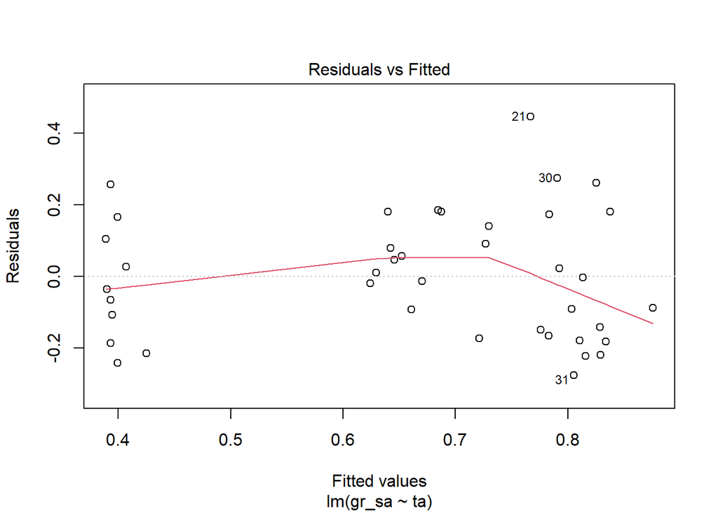

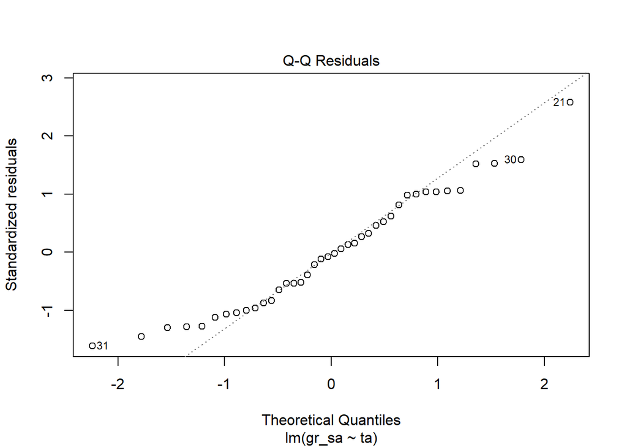

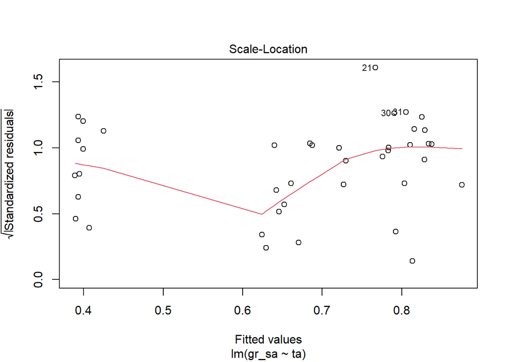

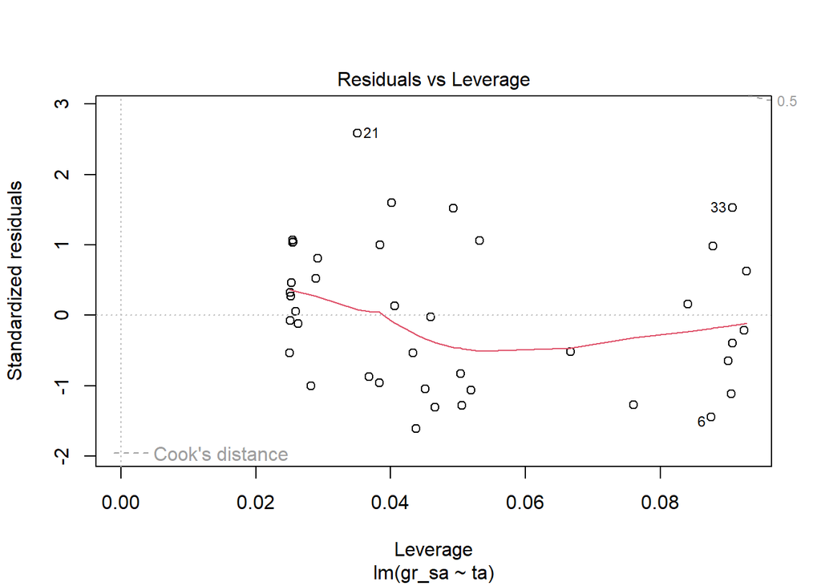

Compare the two models:

```
## Analysis of Variance Table
##
## Model 1: gr_sa ~ ta
## Model 2: gr_sa ~ log(ta)
##   Res.Df    RSS Df Sum of Sq F Pr(>F)
## 1     38 1.1748
## 2     38 1.1401  0  0.034701
```

outcome???

Example of log regression plot:

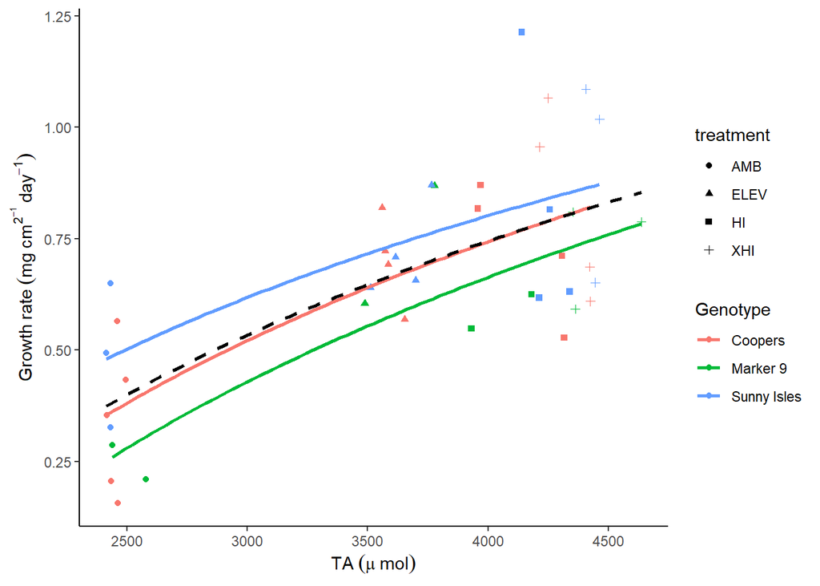

### Linear Extension

#### Linear regression

Linear extension (via ImageJ) with linear regression (t1-t3)

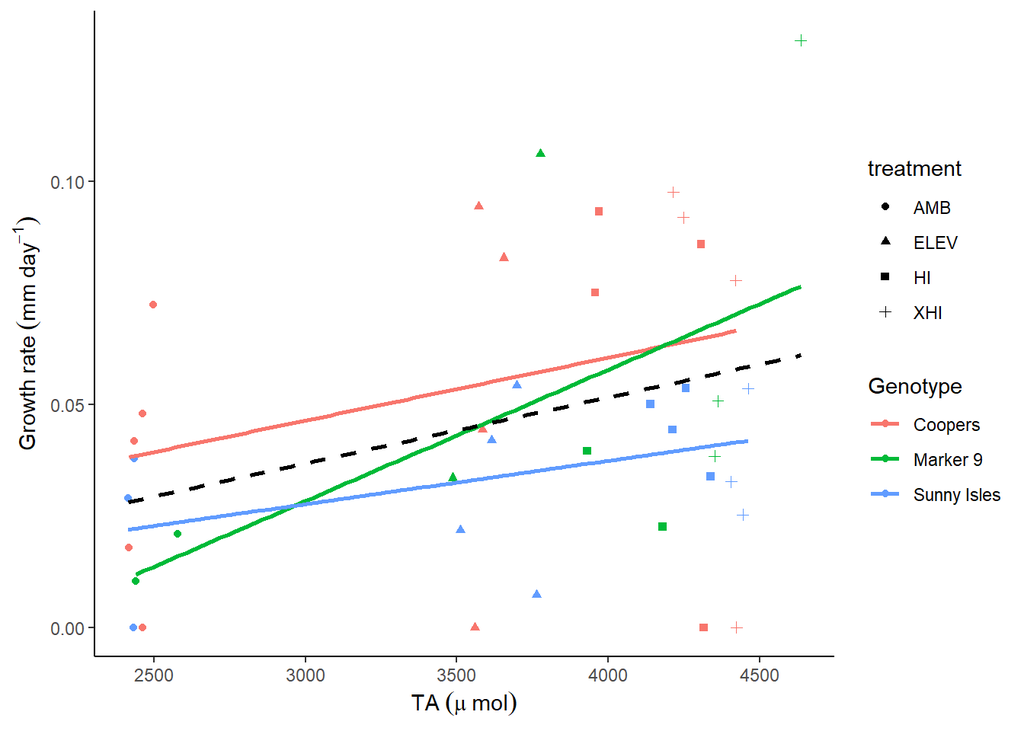

Adding error bars for TA:

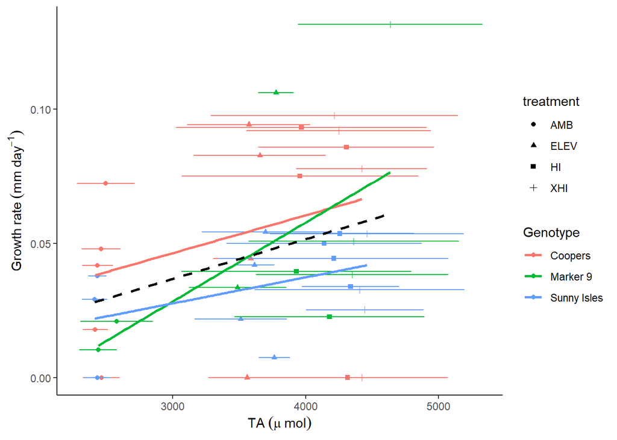

# Carb Chemistry

Was alkalinity statistically different between treatments?

```
##             Df Sum Sq Mean Sq F value Pr(>F)
## treatment    3 22.428   7.476   591.3 <2e-16 ***
## Residuals   36  0.455   0.013
## ---
## Signif. codes:  0 '***' 0.001 '**' 0.01 '*' 0.05 '.' 0.1 ' ' 1
```

```
##   Tukey multiple comparisons of means
##     95% family-wise confidence level
##
## Fit: aov(formula = ta_mmol ~ treatment, data = bw.2)
##
## $treatment
##               diff       lwr       upr     p adj
## ELEV-AMB 1.1656999 1.0302712 1.3011286 0.0000000
## HI-AMB   1.7037780 1.5683493 1.8392067 0.0000000
## XHI-AMB  1.9401692 1.8047406 2.0755979 0.0000000
## HI-ELEV  0.5380781 0.4026495 0.6735068 0.0000000
## XHI-ELEV 0.7744694 0.6390407 0.9098980 0.0000000
## XHI-HI   0.2363912 0.1009625 0.3718199 0.0002108
```

yes…

Stability of treatment over time:

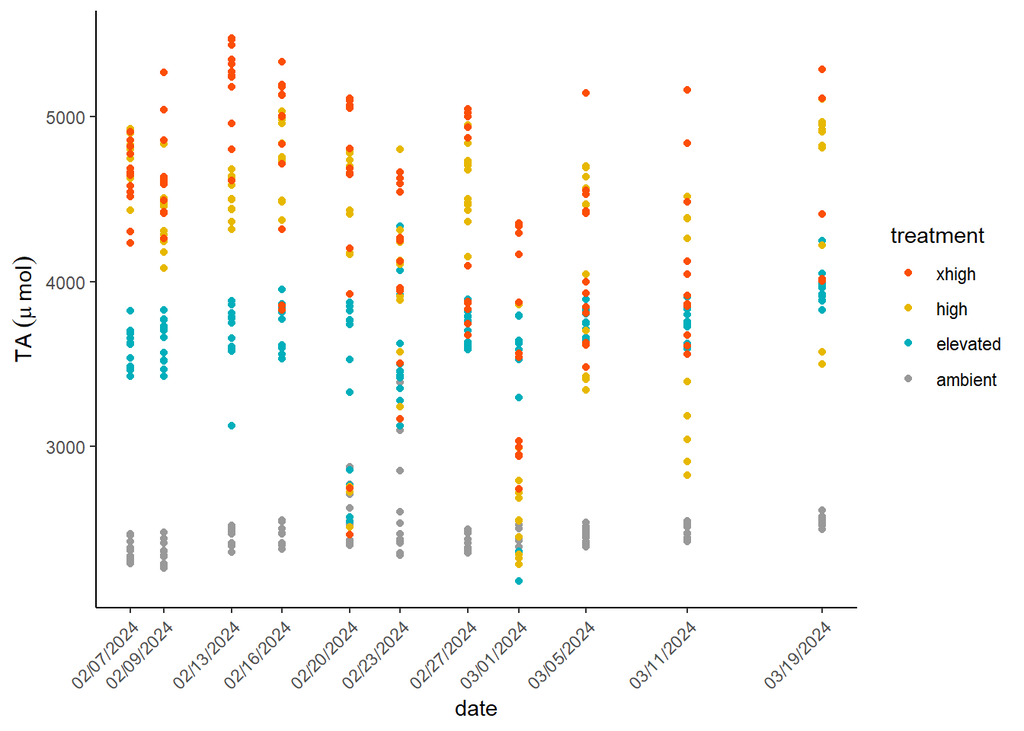

Stability of treatments over time with mean and error bars:

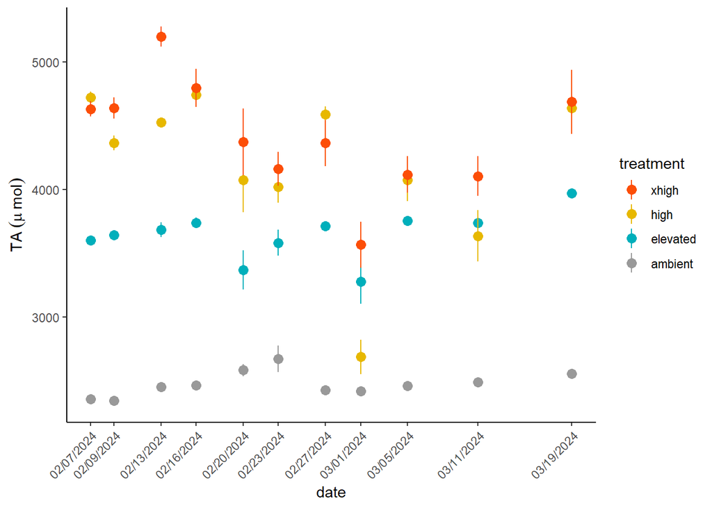